# Lecture 12: Multiple Linear Regression in Python

PSTAT100: Data Science — Concepts and Analysis

John Inston

johninston@ucsb.edu

University of California, Santa Barbara

October 29, 2026

## 🚁 Overview

### Aims of the lecture

- Fit **multiple linear regression** models with `statsmodels` using the formula interface.
- Incorporate **categorical predictors** via dummy variables and interpret their coefficients.
- Read and interpret the **MLR regression summary**.
- **Compare nested models** using partial $F$-tests and information criteria.
- Specify and interpret **interaction terms**.
- Run the full **residual diagnostic panel** and **added-variable plots**.
- Detect multicollinearity with **VIF**.

### 📚 Required Libraries

```python
import numpy as np
import pandas as pd
import matplotlib.pyplot as plt
import seaborn as sns
from scipy.stats import probplot
import statsmodels.formula.api as smf
import statsmodels.api as sm
from statsmodels.stats.anova import anova_lm
from statsmodels.stats.outliers_influence import variance_inflation_factor
from sklearn.datasets import fetch_california_housing
```

### 💅 Figure Styles

```python
sns.set_style('whitegrid')
sns.set_palette('Set2')
```

# The Dataset

## 🐧 Palmer Penguins — Extended Analysis

### Recall from Lecture 10

- SLR with **flipper length alone** gave $R^2 \approx 0.76$ — a strong fit, but not the whole story.
- Residual diagnostics showed **systematic banding** by species — a clear sign of an omitted variable.

```python
penguins = (
    sns.load_dataset('penguins')
    .dropna()
    .reset_index(drop=True)
)
penguins.head()
```

|  | species | island | bill_length_mm | bill_depth_mm | flipper_length_mm | body_mass_g | sex |
| --- | --- | --- | --- | --- | --- | --- | --- |
| 0 | Adelie | Torgersen | 39.1 | 18.7 | 181.0 | 3750.0 | Male |
| 1 | Adelie | Torgersen | 39.5 | 17.4 | 186.0 | 3800.0 | Female |
| 2 | Adelie | Torgersen | 40.3 | 18.0 | 195.0 | 3250.0 | Female |
| 3 | Adelie | Torgersen | 36.7 | 19.3 | 193.0 | 3450.0 | Female |
| 4 | Adelie | Torgersen | 39.3 | 20.6 | 190.0 | 3650.0 | Male |

## Pairplot

```python
sns.pairplot(
    penguins[['body_mass_g', 'flipper_length_mm',
              'bill_length_mm', 'bill_depth_mm', 'species']],
    hue='species', plot_kws={'alpha': 0.5, 's': 25},
    diag_kind='kde', height=1.5, aspect=1.5
)
plt.suptitle('Pairplot of Palmer Penguins Numeric Variables', y=1.01)
plt.show()
```

## Pairplot

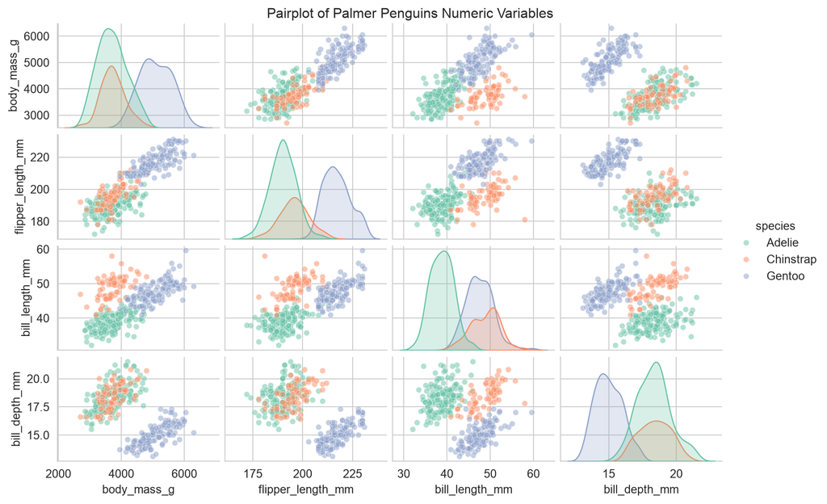

Pairplot of all numeric regression variables, coloured by species. Note the strong species separation across multiple dimensions.

## Correlation Matrix

```python
numeric_cols = ['body_mass_g', 'flipper_length_mm', 'bill_length_mm', 'bill_depth_mm']
corr = penguins[numeric_cols].corr()

fig, ax = plt.subplots(figsize=(7, 5))
mask = np.triu(np.ones_like(corr, dtype=bool))
sns.heatmap(corr, annot=True, fmt='.2f', cmap='coolwarm',
            center=0, square=True, mask=mask, ax=ax,
            cbar_kws={'shrink': 0.8})
ax.set_title('Correlation Matrix: Numeric Variables')
plt.tight_layout(); plt.show()
```

## Correlation Matrix

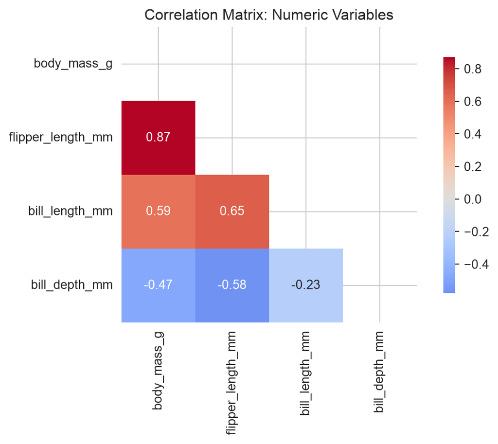

Pearson correlation heatmap. Flipper length and bill length are moderately correlated — a potential multicollinearity concern.

# Fitting MLR with statsmodels

## 🛠️ The Formula Interface for MLR

### Extending what we know

The `statsmodels` formula interface extends naturally from SLR to MLR — just add more terms:

| Formula | Meaning |
| --- | --- |
| `'y ~ x1 + x2'` | Additive model (intercept automatic) |
| `'y ~ x1 + x2 - 1'` | No intercept |
| `'y ~ C(species)'` | Treat `species` as categorical (dummy coding) |
| `'y ~ x1 * x2'` | $x_1 + x_2 + x_1 x_2$ (main effects + interaction) |
| `'y ~ x1 + x1:x2'` | $x_1$ and the interaction term only |
| `'y ~ np.log(x1)'` | Apply transformation inline |

## Model 1: Numeric Predictors Only

### Without species terms

Let’s start with a model that includes all numeric predictors but no species terms.

For response $Y=$`body_mass_g` and predictors $X_1=$`flipper_length_mm`, $X_2=$`bill_length_mm`, $X_3=$`bill_depth_mm`, the formula is:

$$Y_i = \beta_0 + \beta_1 x_{i1} + \beta_2 x_{i2} + \beta_3 x_{i3} + \varepsilon_i,$$

where $\varepsilon_i \sim \mathcal{N}(0, \sigma^2)$.

## Model 1: Python Code

We fit the model and print the summary.

```python
model1 = smf.ols(
    'body_mass_g ~ flipper_length_mm + bill_length_mm + bill_depth_mm',
    data=penguins
).fit()
print(model1.summary())
```

```
                            OLS Regression Results
==============================================================================
Dep. Variable:            body_mass_g   R-squared:                       0.764
Model:                            OLS   Adj. R-squared:                  0.762
Method:                 Least Squares   F-statistic:                     354.9
Date:                Thu, 29 Oct 2026   Prob (F-statistic):          9.26e-103
Time:                        10:14:38   Log-Likelihood:                -2459.8
No. Observations:                 333   AIC:                             4928.
Df Residuals:                     329   BIC:                             4943.
Df Model:                           3
Covariance Type:            nonrobust
=====================================================================================
                        coef    std err          t      P>|t|      [0.025      0.975]
-------------------------------------------------------------------------------------
Intercept         -6445.4760    566.130    -11.385      0.000   -7559.167   -5331.785
flipper_length_mm    50.7621      2.497     20.327      0.000      45.850      55.675
bill_length_mm        3.2929      5.366      0.614      0.540      -7.263      13.849
bill_depth_mm        17.8364     13.826      1.290      0.198      -9.362      45.035
==============================================================================
Omnibus:                        5.596   Durbin-Watson:                   1.968
Prob(Omnibus):                  0.061   Jarque-Bera (JB):                5.469
Skew:                           0.312   Prob(JB):                       0.0649
Kurtosis:                       3.068   Cond. No.                     5.44e+03
==============================================================================

Notes:
[1] Standard Errors assume that the covariance matrix of the errors is correctly specified.
[2] The condition number is large, 5.44e+03. This might indicate that there are
strong multicollinearity or other numerical problems.
```

## Reading the MLR Summary

### Coefficients

```python
print(model1.summary2().tables[1].round(3))
```

```
                      Coef.  Std.Err.       t  P>|t|    [0.025    0.975]
Intercept         -6445.476   566.130 -11.385  0.000 -7559.167 -5331.785
flipper_length_mm    50.762     2.497  20.327  0.000    45.850    55.675
bill_length_mm        3.293     5.366   0.614  0.540    -7.263    13.849
bill_depth_mm        17.836    13.826   1.290  0.198    -9.362    45.035
```

- Each slope is a **partial** effect — holding all other predictors constant.
- `bill_length_mm` has a large $p$-value — once flipper length and depth are in the model, bill length adds little additional information.

### Have we improved on SLR?

```python
model_slr = smf.ols('body_mass_g ~ flipper_length_mm', data=penguins).fit()
rows = {'SLR (flipper only)':    model_slr, 'MLR (+ bill dims)':     model1, }
print(f"{'Model':<24} {'R²':>6} {'Adj. R²':>9} {'AIC':>10} {'BIC':>10}")
print("-" * 61)
for name, m in rows.items():
    print(f"{name:<24} {m.rsquared:>6.4f} " f"{m.rsquared_adj:>9.4f} "
          f"{m.aic:>10.1f} " f"{m.bic:>10.1f}")
```

```
Model                        R²   Adj. R²        AIC        BIC
-------------------------------------------------------------
SLR (flipper only)       0.7621    0.7614     4926.1     4933.8
MLR (+ bill dims)        0.7639    0.7618     4927.6     4942.8
```

- Adjusted $R^2$ improves slightly but both AIC and BIC increase — the added bill length and depth terms do not justify their complexity.

# Categorical Predictors

## 🏷️ Dummy Coding

### How statsmodels handles categorical variables

For a categorical variable with $k$ levels, `statsmodels` creates **$k - 1$ dummy variables** using **treatment (reference) coding**:

- One level is chosen as the **reference category** (alphabetically by default).
- Each dummy variable equals 1 for observations in that category, 0 otherwise.
- The **intercept** gives the expected response for the reference category.
- Each slope gives the **difference** from the reference, holding other variables constant.

For `species` (Adelie, Chinstrap, Gentoo), statsmodels creates:

| Dummy | Value for Adelie | Value for Chinstrap | Value for Gentoo |
| --- | --- | --- | --- |
| `C(species)[T.Chinstrap]` | 0 | 1 | 0 |
| `C(species)[T.Gentoo]` | 0 | 0 | 1 |

Adelie is the **reference category** (first alphabetically).

## Dummy Impact

### What are we really doing?

- By adding `C(species)`, we allow the model to fit **different intercepts** for each species.
- This results in **3 parallel regression planes** (one per species) rather than a single plane for all data.

### Visualising the effect of adding species (SLR + species)

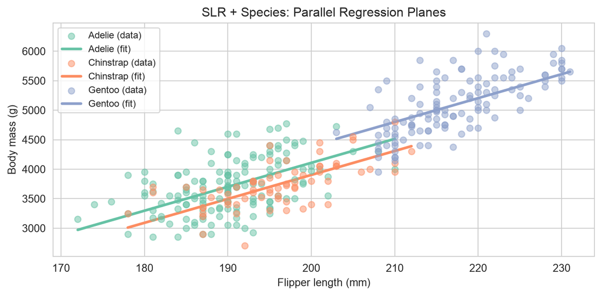

Adding species allows the model to fit separate intercepts for each species, capturing much of the previously observed residual structure.

## Model 2: Adding Species

### Let’s add Species

Now we modify our MLR model to include `C(species)` as a **categorical predictor**. We define **indicator variables** for Chinstrap and Gentoo, with Adelie as the reference category.

$$Y_i = \beta_0 + \beta_1 x_{1i} + \beta_2 x_{2i} + \beta_3 x_{3i} +
\beta_4 d_{Ci}+ \beta_5 d_{Gi} + \varepsilon_i,$$

$$\varepsilon_i \overset{\text{iid}}{\sim} \mathcal{N}(0, \sigma^2),$$

where $d_{Ci}$ and $d_{Gi}$ are the **dummy variables** for Chinstrap and Gentoo, respectively.

- We have added **two parameters** ($\beta_4$, $\beta_5$).
- We will need to check if these parameters **sufficiently improve model fit** to justify their inclusion (partial $F$-test, AIC/BIC comparison).

## Model 2: Python Code

We add `C(species)` to the formula and fit the model:

```python
model2 = smf.ols(
    'body_mass_g ~ flipper_length_mm + bill_length_mm + bill_depth_mm + C(species)',
    data=penguins
).fit()
print(model2.summary())
```

```
                            OLS Regression Results
==============================================================================
Dep. Variable:            body_mass_g   R-squared:                       0.849
Model:                            OLS   Adj. R-squared:                  0.847
Method:                 Least Squares   F-statistic:                     369.1
Date:                Thu, 29 Oct 2026   Prob (F-statistic):          4.22e-132
Time:                        10:14:38   Log-Likelihood:                -2384.8
No. Observations:                 333   AIC:                             4782.
Df Residuals:                     327   BIC:                             4805.
Df Model:                           5
Covariance Type:            nonrobust
===========================================================================================
                              coef    std err          t      P>|t|      [0.025      0.975]
-------------------------------------------------------------------------------------------
Intercept               -4282.0802    497.832     -8.601      0.000   -5261.438   -3302.723
C(species)[T.Chinstrap]  -496.7583     82.469     -6.024      0.000    -658.995    -334.521
C(species)[T.Gentoo]      965.1983    141.770      6.808      0.000     686.301    1244.096
flipper_length_mm          20.2264      3.135      6.452      0.000      14.059      26.394
bill_length_mm             39.7184      7.227      5.496      0.000      25.501      53.936
bill_depth_mm             141.7714     19.163      7.398      0.000     104.072     179.470
==============================================================================
Omnibus:                        7.321   Durbin-Watson:                   2.247
Prob(Omnibus):                  0.026   Jarque-Bera (JB):                7.159
Skew:                           0.348   Prob(JB):                       0.0279
Kurtosis:                       3.179   Cond. No.                     6.01e+03
==============================================================================

Notes:
[1] Standard Errors assume that the covariance matrix of the errors is correctly specified.
[2] The condition number is large, 6.01e+03. This might indicate that there are
strong multicollinearity or other numerical problems.
```

## Interpreting the Species Coefficients

### The constant impact of species on body mass

```python
params = model2.params
ci     = model2.conf_int()

for name in ['C(species)[T.Chinstrap]', 'C(species)[T.Gentoo]']:
    short = name.replace('C(species)[T.', '').replace(']', '')
    print(f"{short}: {params[name]:+.1f} g   "
          f"95% CI: ({ci.loc[name, 0]:.1f},  {ci.loc[name, 1]:.1f})")
```

```
Chinstrap: -496.8 g   95% CI: (-659.0,  -334.5)
Gentoo: +965.2 g   95% CI: (686.3,  1244.1)
```

### How to read these

- These are differences relative to the reference category (Adelie).
- **`Gentoo`**: holding all numeric measurements constant, Geintoo penguins weigh approximately 965g *more* than Adelie penguins on average.
- **`Chinstrap`**: similarly, Chinstrap penguins weight approximately 497g less than Adelie penguins on average **after controlling for** flipper length and bill measurements.
- These are **within-measurement** comparisons: given two penguins with identical flipper and bill values, how much does **species alone** account for?

## Visualising the Categorical Model

We produce a multiplot of observed vs. fitted values and residuals vs. fitted for the MLR model.

```python
fig, axes = plt.subplots(1, 2, figsize=(13, 5))
sp_colors = penguins['species'].map({'Adelie': 0, 'Chinstrap': 1, 'Gentoo': 2})

# Observed vs. Fitted
axes[0].scatter(model2.fittedvalues, penguins['body_mass_g'],
                c=sp_colors, cmap='Set2', alpha=0.6, s=30)
lims = [penguins['body_mass_g'].min() - 200, penguins['body_mass_g'].max() + 200]
axes[0].plot(lims, lims, 'k--', lw=1.5, label='Perfect fit')
axes[0].set_xlabel('Fitted values $\\hat{y}$')
axes[0].set_ylabel('Observed $y$')
axes[0].set_title('Observed vs. Fitted — Model 2 (+Species)')
axes[0].legend()

# Residuals vs. Fitted
axes[1].scatter(model2.fittedvalues, model2.resid,
                c=sp_colors, cmap='Set2', alpha=0.6, s=30)
axes[1].axhline(0, color='crimson', lw=1.5, linestyle='--')
lowess = sm.nonparametric.lowess(model2.resid, model2.fittedvalues, frac=0.5)
axes[1].plot(lowess[:, 0], lowess[:, 1], 'crimson', lw=2, label='LOWESS')
axes[1].set_xlabel('Fitted values $\\hat{y}$')
axes[1].set_ylabel('Residuals')
axes[1].set_title('Residuals vs. Fitted — Model 2 (+Species)')
axes[1].legend()

plt.tight_layout(); plt.show()
```

## Visualising the Categorical Model

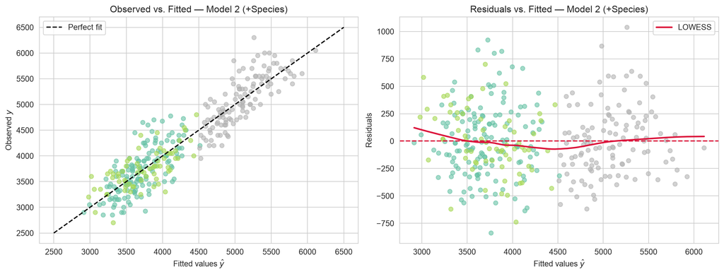

Left: observed vs. fitted values coloured by species — the model now captures species-level structure. Right: residuals vs. fitted — the banding visible in the SLR model (Lecture 10) is substantially reduced.

# Model Comparison

## 🔍 Partial $F$-Test with `anova_lm`

### Does adding species significantly improve the fit?

We compare:

- **Reduced (Model 1)**: `body_mass_g ~ flipper + bill_length + bill_depth`
- **Full (Model 2)**: adds `C(species)` — 2 extra parameters (Chinstrap, Gentoo dummies)

```python
anova_table = anova_lm(model1, model2)
print(anova_table.round(4))
```

```
   df_resid           ssr  df_diff       ss_diff        F  Pr(>F)
0     329.0  5.081491e+07      0.0           NaN      NaN     NaN
1     327.0  3.239767e+07      2.0  1.841724e+07  92.9455     0.0
```

- A very small $p$-value means: yes, species terms **jointly** and significantly improve the fit.
- The $F$-statistic measures the average improvement in fit per additional parameter.
- `anova_lm` automatically computes the correct $F_{q,\, n-p-1}$ statistic.

## Summary Comparison of All Models

```python
models = {
    'SLR (flipper)':   model_slr,
    'MLR numeric':     model1,
    'MLR + species':   model2,
}

print(f"{'Model':<22} {'R²':>6} {'Adj. R²':>9} {'AIC':>10} {'BIC':>10}")
print("-" * 59)
for name, m in models.items():
    print(f"{name:<22} {m.rsquared:>6.4f} "
          f"{m.rsquared_adj:>9.4f} "
          f"{m.aic:>10.1f} "
          f"{m.bic:>10.1f}")
```

```
Model                      R²   Adj. R²        AIC        BIC
-----------------------------------------------------------
SLR (flipper)          0.7621    0.7614     4926.1     4933.8
MLR numeric            0.7639    0.7618     4927.6     4942.8
MLR + species          0.8495    0.8472     4781.7     4804.5
```

> Every metric — Adj. $R^2$, AIC, BIC — improves substantially when species is added. The partial $F$-test confirms this improvement is statistically significant.

# Interaction Terms

## 🤝 What Is an Interaction?

An **interaction** between $X_j$ and $X_k$ allows the **slope** of $X_j$ to depend on the value of $X_k$:

$$Y_i = \beta_0 + \beta_1 x_{j} + \beta_2 x_{k} + \beta_{jk}\,x_{j}\,x_{k} + \varepsilon_i.$$

- Without the interaction: the effect of $X_j$ on $Y$ is always $\beta_1$ regardless of $X_k$.
- With the interaction: the effect of $X_j$ is $\beta_1 + \beta_{jk}\,x_k$ — it **changes with $x_k$**.

### A natural question for penguins

> Does the relationship between **flipper length** and **body mass** differ by **species**?
- Each species may have a different slope, not just a different intercept.
- We test this with: `flipper_length_mm * C(species)`.

## Model 3: Adding the interaction

To allow species-specific slopes for flipper length, we add the interaction term `flipper_length_mm * C(species)` to the formula. This expands to:

$$Y_i = \beta_0 + \beta_1 x_{1i} + \beta_2 x_{2i} + \beta_3 x_{3i} +
\beta_4 d_{Ci} + \beta_5 d_{Gi} + \beta_6 x_{1i} d_{Ci} + \beta_7 x_{1i} d_{Gi} + \varepsilon_i,$$

$$\varepsilon_i \overset{\text{iid}}{\sim} \mathcal{N}(0, \sigma^2),$$

where $x_{1i}$ is flipper length, $d_{Ci}$ and $d_{Gi}$ are the species dummies, and $\beta_6$, $\beta_7$ capture how the flipper length slope changes for Chinstrap and Gentoo relative to Adelie.

## Model 3: Python Code

We fit the interaction model and print the summary.

```python
model3 = smf.ols(
    'body_mass_g ~ flipper_length_mm * C(species) + bill_depth_mm + bill_length_mm',
    data=penguins
).fit()
print(model3.summary())
```

```
                            OLS Regression Results
==============================================================================
Dep. Variable:            body_mass_g   R-squared:                       0.851
Model:                            OLS   Adj. R-squared:                  0.848
Method:                 Least Squares   F-statistic:                     266.1
Date:                Thu, 29 Oct 2026   Prob (F-statistic):          1.91e-130
Time:                        10:14:39   Log-Likelihood:                -2382.7
No. Observations:                 333   AIC:                             4781.
Df Residuals:                     325   BIC:                             4812.
Df Model:                           7
Covariance Type:            nonrobust
=============================================================================================================
                                                coef    std err          t      P>|t|      [0.025      0.975]
-------------------------------------------------------------------------------------------------------------
Intercept                                 -4033.9617    772.128     -5.224      0.000   -5552.961   -2514.962
C(species)[T.Chinstrap]                     736.4042   1304.386      0.565      0.573   -1829.701    3302.510
C(species)[T.Gentoo]                       -714.7245   1256.975     -0.569      0.570   -3187.558    1758.109
flipper_length_mm                            19.3220      4.168      4.636      0.000      11.122      27.522
flipper_length_mm:C(species)[T.Chinstrap]    -6.1885      6.734     -0.919      0.359     -19.436       7.059
flipper_length_mm:C(species)[T.Gentoo]        7.8992      6.070      1.301      0.194      -4.042      19.841
bill_depth_mm                               141.0182     19.164      7.358      0.000     103.317     178.720
bill_length_mm                               38.1121      7.295      5.225      0.000      23.762      52.463
==============================================================================
Omnibus:                        8.313   Durbin-Watson:                   2.207
Prob(Omnibus):                  0.016   Jarque-Bera (JB):                8.202
Skew:                           0.370   Prob(JB):                       0.0166
Kurtosis:                       3.208   Cond. No.                     2.16e+04
==============================================================================

Notes:
[1] Standard Errors assume that the covariance matrix of the errors is correctly specified.
[2] The condition number is large, 2.16e+04. This might indicate that there are
strong multicollinearity or other numerical problems.
```

## Visualising the Interaction

We produce a plot to help visualize the impact of the interaction terms — separate regression lines for each species.

```python
colors = {'Adelie': '#66c2a5', 'Chinstrap': '#fc8d62', 'Gentoo': '#8da0cb'}
fig, ax = plt.subplots(figsize=(10, 6))

for sp, grp in penguins.groupby('species'):
    ax.scatter(grp['flipper_length_mm'], grp['body_mass_g'],
               color=colors[sp], alpha=0.5, s=35, zorder=3, label=f'{sp} (data)')
    x_range = pd.DataFrame({
        'flipper_length_mm': np.linspace(
            grp['flipper_length_mm'].min(),
            grp['flipper_length_mm'].max(), 100),
        'species': sp,
        'bill_depth_mm': penguins['bill_depth_mm'].mean(),
        'bill_length_mm': penguins['bill_length_mm'].mean()
    })
    y_pred = model3.predict(x_range)
    ax.plot(x_range['flipper_length_mm'], y_pred,
            color=colors[sp], lw=2.5, label=f'{sp} (fit)')

ax.set_xlabel('Flipper length (mm)')
ax.set_ylabel('Body mass (g)')
ax.set_title('Interaction Model: Species $\\times$ Flipper Length')
ax.legend(fontsize=9, ncol=2)
plt.tight_layout(); plt.show()
```

## Visualising the Interaction

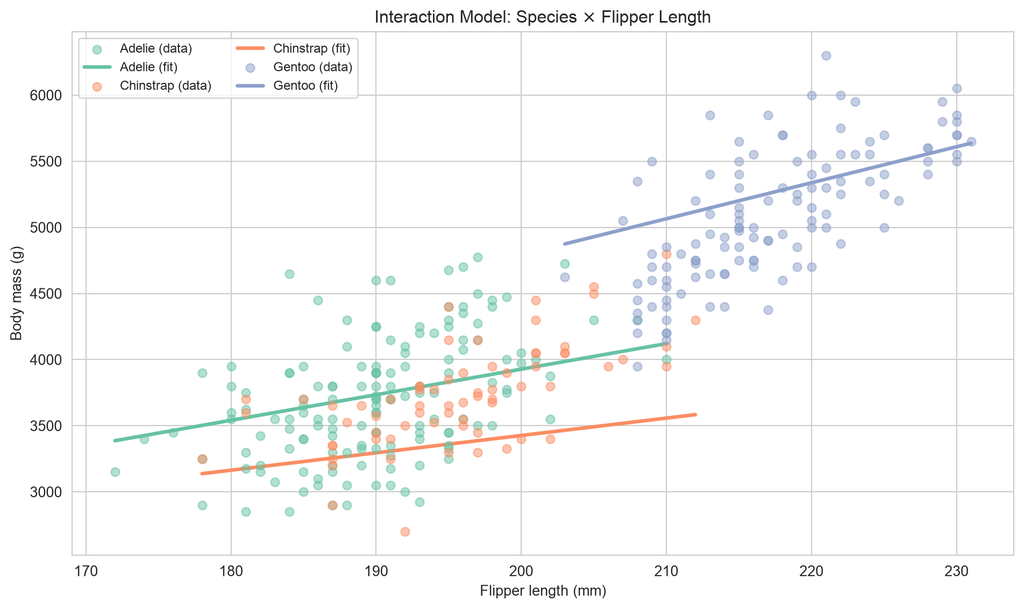

Interaction model: each species has its own regression slope (not just intercept). The slopes are broadly similar, suggesting the interaction terms may not add much beyond different intercepts.

## Testing Whether the Interaction Terms Help

### Lots of Parameters, but do they improve fit?

- Model 3 already has 8 parameters (intercept + 3 numeric slopes + 2 species dummies + 2 interaction terms).
- We are interested to test whether these parameters are significant and whether they provide enough improvement.

```python
anova_int = anova_lm(model2, model3)
print(anova_int.round(4))
```

```
   df_resid           ssr  df_diff      ss_diff       F  Pr(>F)
0     327.0  3.239767e+07      0.0          NaN     NaN     NaN
1     325.0  3.197996e+07      2.0  417706.1568  2.1225  0.1214
```

- Compare the $p$-value to $\alpha = 0.05$.
- If the interaction terms are not significant, Model 2 (parallel slopes, different intercepts) is preferred — it is simpler and nearly as well-fitting.
- This is the **principle of parsimony**: prefer the simpler model when the more complex one does not significantly improve fit.

# Residual Diagnostics for MLR

## 🔬 The Full Diagnostic Panel

```python
fitted   = model2.fittedvalues
residual = model2.resid
resid_std = residual / np.sqrt(np.sum(residual**2) / model2.df_resid)
sqrt_abs  = np.sqrt(np.abs(resid_std))
influence = model2.get_influence()
cooks_d   = influence.cooks_distance[0]
threshold = 4 / len(penguins)

fig, axes = plt.subplots(2, 2, figsize=(13, 6))

# 1. Residuals vs Fitted
axes[0,0].scatter(fitted, residual, alpha=0.45, color='steelblue', s=25, zorder=3)
axes[0,0].axhline(0, color='crimson', lw=1.5, linestyle='--')
lw1 = sm.nonparametric.lowess(residual, fitted, frac=0.5)
axes[0,0].plot(lw1[:,0], lw1[:,1], 'crimson', lw=2)
axes[0,0].set_xlabel('Fitted values'); axes[0,0].set_ylabel('Residuals')
axes[0,0].set_title('Residuals vs. Fitted')

# 2. Normal Q-Q
qq = probplot(residual, dist='norm')
axes[0,1].scatter(qq[0][0], qq[0][1], alpha=0.5, color='steelblue', s=25, zorder=3)
axes[0,1].plot(qq[0][0], qq[1][1] + qq[1][0]*qq[0][0], 'crimson', lw=2, label='Reference')
axes[0,1].set_xlabel('Theoretical quantiles'); axes[0,1].set_ylabel('Sample quantiles')
axes[0,1].set_title('Normal Q-Q'); axes[0,1].legend(fontsize=9)

# 3. Scale-Location
axes[1,0].scatter(fitted, sqrt_abs, alpha=0.45, color='steelblue', s=25, zorder=3)
lw2 = sm.nonparametric.lowess(sqrt_abs, fitted, frac=0.5)
axes[1,0].plot(lw2[:,0], lw2[:,1], 'crimson', lw=2)
axes[1,0].set_xlabel('Fitted values')
axes[1,0].set_ylabel('$\\sqrt{|\\mathrm{Std.\\ Residuals}|}$')
axes[1,0].set_title('Scale-Location')

# 4. Cook's Distance
axes[1,1].stem(range(len(cooks_d)), cooks_d,
               linefmt='steelblue', markerfmt='o', basefmt=' ')
axes[1,1].axhline(threshold, color='crimson', linestyle='--',
                   label=f'4/n = {threshold:.3f}')
axes[1,1].set_xlabel('Observation index')
axes[1,1].set_ylabel("Cook's $D_i$")
axes[1,1].set_title("Cook's Distance"); axes[1,1].legend(fontsize=9)

plt.suptitle('MLR Diagnostic Panel — Model 2 (+Species)', fontsize=14, y=1.01)
plt.tight_layout(); plt.show()
```

## 🔬 The Full Diagnostic Panel

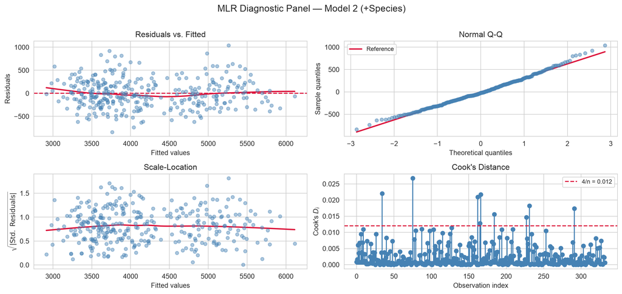

Four-panel diagnostic plot for Model 2 (+species). Compare with the SLR diagnostics from Lecture 10 — adding species substantially reduces the residual structure.

## Added-Variable (Partial Regression) Plots

### What are they?

- Show the **marginal effect** of one predictor after removing the linear influence of all other predictors.
- Plot: residuals of $Y \sim \{\text{all others}\}$ vs. residuals of $X_j \sim \{\text{all others}\}$.
- The slope in this plot **equals** $\hat{\beta}_j$ in the full model.
- Useful for visualising partial effects and spotting leverage/influence for a specific predictor.

```python
fig = sm.graphics.plot_partregress_grid(
    model2, fig=plt.figure(figsize=(13, 5))
)
fig.suptitle('Added-Variable Plots — Model 2 (+Species)', fontsize=13, y=1.02)
plt.tight_layout(); plt.show()
```

## Added-Variable (Partial Regression) Plots

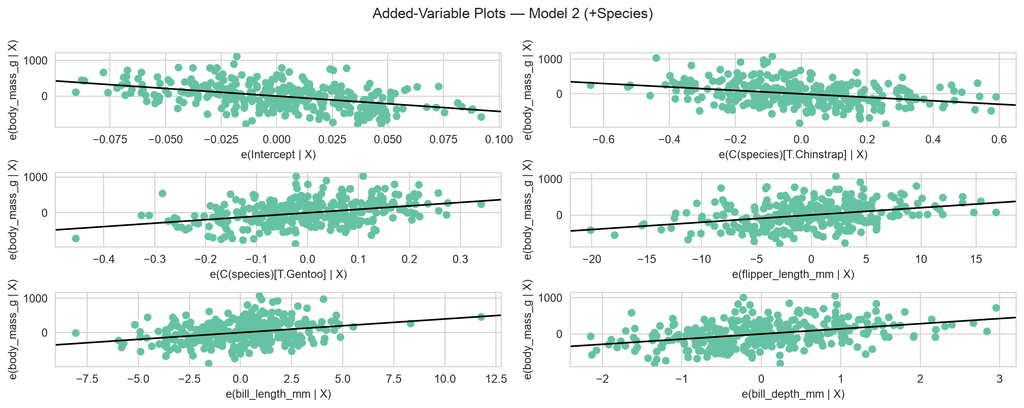

# Multicollinearity in Practice

## What is Multicollinearity?

**Multicollinearity** occurs when two or more predictors in a regression model are highly correlated with each other.

### Why it causes problems

- The model cannot cleanly separate the individual effects of correlated predictors.
- **Coefficient estimates become unstable** — small changes in the data can produce large swings in $\hat{\beta}$.
- **Standard errors inflate**, making $t$-statistics small and $p$-values large even when predictors genuinely matter.
- The model’s *predictions* may still be accurate, but **interpretation of individual coefficients** becomes unreliable.

## The Variance Inflation Factor (VIF)

The **VIF** for predictor $X_j$ measures how much its variance is inflated due to correlation with the other predictors:

$$\text{VIF}_j = \frac{1}{1 - R^2_j},$$

where $R^2_j$ is the $R^2$ from regressing $X_j$ on all other predictors.

- $\text{VIF} = 1$: no collinearity.
- $\text{VIF} > 5$: moderate concern; inspect carefully.
- $\text{VIF} > 10$: serious collinearity; coefficients are likely unreliable.

## ⚠️ Computing VIF in Python

To compute the VIF we use the `variance_inflation_factor` function from `statsmodels`. We need to create a design matrix that includes all numeric predictors (and a constant) and then compute the VIF for each predictor.

```python
numeric_preds = ['flipper_length_mm', 'bill_length_mm', 'bill_depth_mm']
X_vif = sm.add_constant(penguins[numeric_preds]).values

vif_df = pd.DataFrame({
    'Predictor': numeric_preds,
    'VIF': [variance_inflation_factor(X_vif, i + 1)
            for i in range(len(numeric_preds))]
}).round(3)

print(vif_df.to_string(index=False))

fig, ax = plt.subplots(figsize=(7, 3))
ax.barh(vif_df['Predictor'], vif_df['VIF'],
        color='steelblue', alpha=0.8)
ax.axvline(5,  color='orange', lw=2, linestyle='--', label='VIF = 5')
ax.axvline(10, color='crimson', lw=2, linestyle='--', label='VIF = 10')
ax.set_xlabel('VIF')
ax.set_title('Variance Inflation Factors — Model 2 Numeric Predictors')
ax.legend(fontsize=9)
plt.tight_layout(); plt.show()
```

## ⚠️ Computing VIF in Python

```
        Predictor   VIF
flipper_length_mm 2.633
   bill_length_mm 1.851
    bill_depth_mm 1.593
```

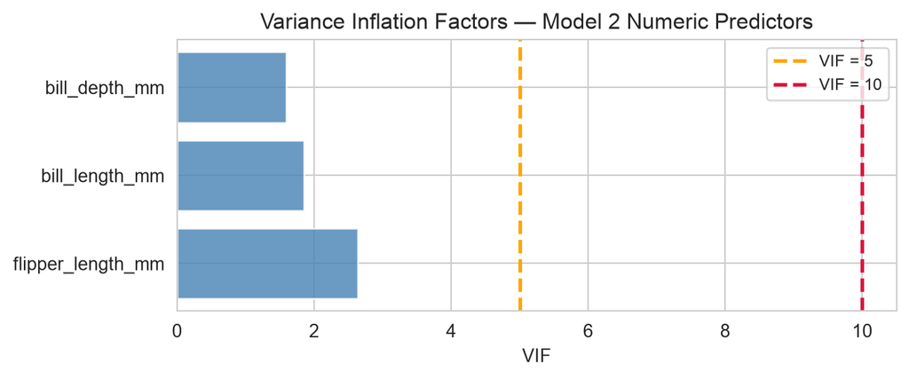

VIF values for the numeric predictors in Model 2. Values are all below 5, suggesting multicollinearity is not a serious concern here.

## A Note on What MLR Cannot Tell Us

### What we should not conclude

- **Causation**: the model describes associations, not mechanisms.
- **Completeness**: other omitted variables (age, sex, diet) likely explain residual variation.
- **Extrapolation**: predictions are reliable only within the observed range of predictor values.

> These limitations motivate moving to **generalised models** — extending regression beyond continuous Gaussian responses.

## Conclusion

### ✅ What we covered

- **Fitting MLR** with `statsmodels` using the formula interface.
- **Categorical predictors**: dummy coding, treatment contrasts, and interpreting species coefficients.
- **Reading the MLR summary**: adj. $R^2$, overall $F$-test, and partial $t$-tests.
- **Model comparison**: partial $F$-test via `anova_lm`; AIC/BIC and adj. $R^2$ table.
- **Interaction terms**: `x1 * x2` syntax; visualising species-specific slopes; testing necessity with partial $F$.
- **Residual diagnostics**: the four-panel plot; added-variable plots via `plot_partregress_grid`.
- **VIF**: detecting multicollinearity with `variance_inflation_factor`.

### 📅 What’s next?

- Model Selection methods: stepwise regression, regularisation (Lasso, Ridge), and best subsets.
- Logistic Regression.